# Practical Machine Learning Project

## Fitting a Tree to determine variable importance

To begin somewhere, let’s try to fit a tree model and then fit similar models to determine best model selection using an apples to apples comparison.

```r
#Use the cached model if it exists, otherwise train a new model
if(file.exists(rds.modelTree)) {
    modelTree = readRDS(rds.modelTree)
} else {
    set.seed(1138)
    modelTree <- train(classe ~ .,
                   method = "rpart",
                   data = training,
                   trControl = fitControl,
                   verbose = FALSE)
    saveRDS(modelTree, file=rds.modelTree)
}
```

From the first model, let’s see if we can narrow down the list of variables to the most important predictors.

```r
imp <- varImp(modelTree,surrogates=FALSE,competes=TRUE)$importance
subset(imp,Overall>0)
```

```
FALSE                     Overall
FALSE accel_arm_x        24.66958
FALSE accel_belt_z       43.38959
FALSE accel_dumbbell_y   15.75390
FALSE magnet_arm_x       26.20471
FALSE magnet_belt_y      41.37231
FALSE magnet_dumbbell_x  18.34869
FALSE magnet_dumbbell_y  51.43652
FALSE magnet_dumbbell_z  17.48136
FALSE pitch_forearm     100.00000
FALSE roll_arm           16.01140
FALSE roll_belt          70.09482
FALSE roll_dumbbell      18.86450
FALSE roll_forearm       73.65696
FALSE total_accel_belt   35.66874
FALSE yaw_belt           41.61794
```

Looks like we can remove gyros parameters safely. Let’s graph the most important variables first to see how predictive they might be. See appendix **PlotImportantVariables** for R code.

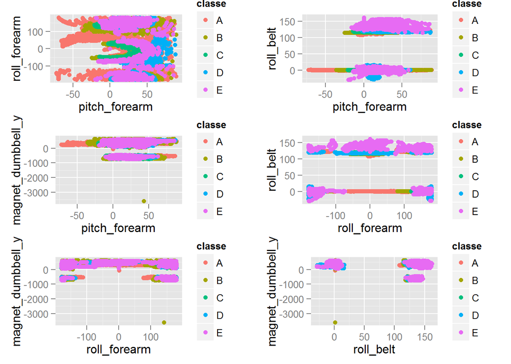

# Initial Models

In this section, we now do several models using the reduced predictors from the first exploration. We will continue to try to simplify the model as we go on.

## First test model - CART

Now let’s train a Tree model without gyros. First we define a new training set and then train a second Tree with fewer paramters. See appendix **SetSmallerTrainingSet** for R Code.

```
FALSE [1] TRUE TRUE TRUE
```

```
FALSE CART
FALSE
FALSE 13737 samples
FALSE    40 predictor
FALSE     5 classes: 'A', 'B', 'C', 'D', 'E'
FALSE
FALSE No pre-processing
FALSE Resampling: Cross-Validated (10 fold, repeated 10 times)
FALSE
FALSE Summary of sample sizes: 12365, 12363, 12365, 12364, 12363, 12363, ...
FALSE
FALSE Resampling results across tuning parameters:
FALSE
FALSE   cp          Accuracy   Kappa       Accuracy SD  Kappa SD
FALSE   0.03458448  0.5045425  0.35332253  0.01428519   0.01910204
FALSE   0.06147221  0.4122714  0.20239736  0.06083677   0.10249945
FALSE   0.11433221  0.3205365  0.05516644  0.03871594   0.05900361
FALSE
FALSE Accuracy was used to select the optimal model using  the largest value.
FALSE The final value used for the model was cp = 0.03458448.
```

Fantastic, we reduced predictor variable count from 52 to 40 and maintained the same accuracy . We will use this lower number and try a few different models for initial training model selection. Later on we will tweak the actual parameters for the best model selected. Let’s review the tree diagram first.

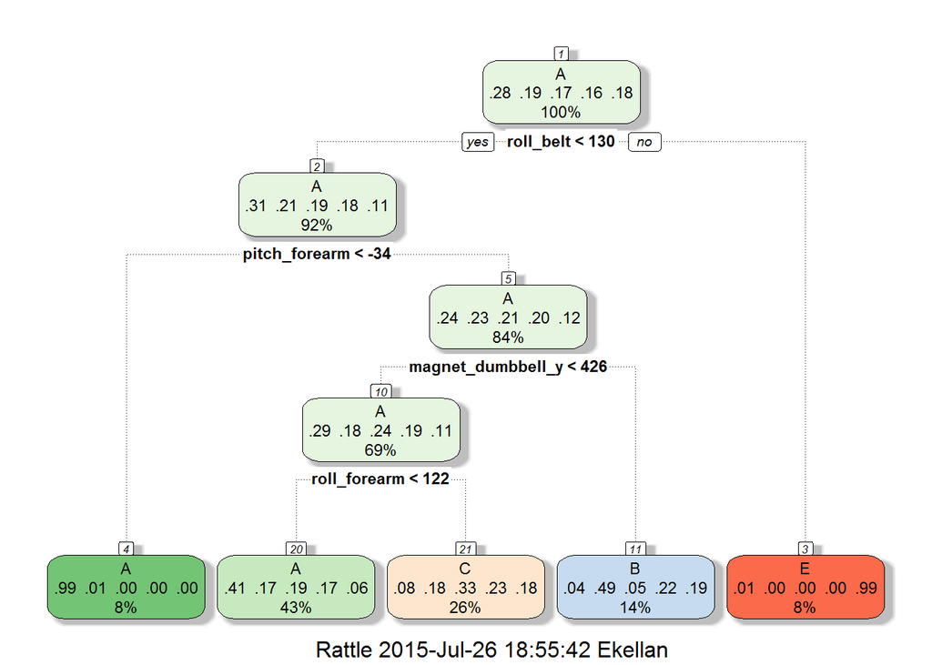

## Random Forest Tuning

```r
if(file.exists(rds.modelRf30)) {
    modelRf30 = readRDS(rds.modelRf30)
} else {
    registerDoParallel(cores=1)
    set.seed(1138)
    modelRf30 <- train(classe ~ .,
                   method = "rf",
                   data = training3,
                   trControl = fitControl,
                   prox = TRUE,
                   verbose = FALSE)
    saveRDS(modelRf30, file=rds.modelRf30)
}

if(file.exists(rds.modelRf)) {
    modelRf = readRDS(rds.modelRf)
} else {
    registerDoParallel(cores=1)
    set.seed(1138)
    modelRf <- train(classe ~ .,
                   method = "rf",
                   data = training2,
                   trControl = fitControl,
                   prox = TRUE,
                   verbose = FALSE)
    saveRDS(modelRf, file=rds.modelRf)
}
```

# Model Selection

So with reduced components in PCA and some additional models trained, we are ready to begin model selection. For this I am comparing models by accuracy.

```r
results <- cbind(c("CART","LDA","LDA_P","QDA","QDA_P","NB","GBM"),
                 rbind(rCart,rLda,rLdaP,rQda,rQdaP,rNb,rGbm))
results <- as.data.frame(results)
names(results) <- c("Model","Accuracy")
results$Accuracy <- as.numeric(as.character(results$Accuracy))
results <- results[order(results[,2],decreasing=TRUE),]
results
```

```
FALSE       Model  Accuracy
FALSE rGbm    GBM 0.9574653
FALSE rQda    QDA 0.8858639
FALSE rNb      NB 0.7251727
FALSE rQdaP QDA_P 0.7060723
FALSE rLda    LDA 0.6933179
FALSE rLdaP LDA_P 0.5388148
FALSE rCart  CART 0.5045425
```

From this result, our best completed models are `gbm` with accuracy of 0.9574653 and `qda` with accuracy of 0.8858639. Note that no model that was testing with Principal Component Analysis performed well. Thus, we select based on best accuracy `gbm`, the details of which you can see below:

```r
modelGbm
```

```
FALSE Stochastic Gradient Boosting
FALSE
FALSE 13737 samples
FALSE    40 predictor
FALSE     5 classes: 'A', 'B', 'C', 'D', 'E'
FALSE
FALSE No pre-processing
FALSE Resampling: Cross-Validated (10 fold, repeated 10 times)
FALSE
FALSE Summary of sample sizes: 12365, 12363, 12365, 12364, 12363, 12363, ...
FALSE
FALSE Resampling results across tuning parameters:
FALSE
FALSE   interaction.depth  n.trees  Accuracy   Kappa      Accuracy SD
FALSE   1                   50      0.7418356  0.6729108  0.011545226
FALSE   1                  100      0.8089980  0.7582257  0.011636646
FALSE   1                  150      0.8443475  0.8030316  0.010183827
FALSE   2                   50      0.8481989  0.8076307  0.009821325
FALSE   2                  100      0.9027521  0.8769425  0.008740784
FALSE   2                  150      0.9276627  0.9084755  0.007738258
FALSE   3                   50      0.8907402  0.8616804  0.008789917
FALSE   3                  100      0.9377812  0.9212776  0.006669372
FALSE   3                  150      0.9574653  0.9461831  0.005410326
FALSE   Kappa SD
FALSE   0.014603413
FALSE   0.014691391
FALSE   0.012872118
FALSE   0.012449678
FALSE   0.011059147
FALSE   0.009789591
FALSE   0.011123414
FALSE   0.008436448
FALSE   0.006847679
FALSE
FALSE Tuning parameter 'shrinkage' was held constant at a value of 0.1
FALSE
FALSE Tuning parameter 'n.minobsinnode' was held constant at a value of 10
FALSE Accuracy was used to select the optimal model using  the largest value.
FALSE The final values used for the model were n.trees = 150,
FALSE  interaction.depth = 3, shrinkage = 0.1 and n.minobsinnode = 10.
```

## Confusion Matrix

Let’s run the Confusion matrix now on the Out of Sample Test data for the top 2 models as thest look the most promising. See appendix **ConfusionMatrix** for the R code.

## Confusion Matrix - Quadratic discriminant analysis

See **ConfusionMatrixQda** for R code.

```
FALSE Confusion Matrix and Statistics
FALSE
FALSE           Reference
FALSE Prediction    A    B    C    D    E
FALSE          A 1562   53   12   43    4
FALSE          B   75  927  117    5   15
FALSE          C    2   40  968   10    6
FALSE          D    1   10   93  846   14
FALSE          E    3   37   47   36  959
FALSE
FALSE Overall Statistics
FALSE
FALSE                Accuracy : 0.8941
FALSE                  95% CI : (0.886, 0.9019)
FALSE     No Information Rate : 0.2792
FALSE     P-Value [Acc > NIR] : < 2.2e-16
FALSE
FALSE                   Kappa : 0.8663
FALSE  Mcnemar's Test P-Value : < 2.2e-16
FALSE
FALSE Statistics by Class:
FALSE
FALSE                      Class: A Class: B Class: C Class: D Class: E
FALSE Sensitivity            0.9507   0.8688   0.7825   0.9000   0.9609
FALSE Specificity            0.9736   0.9560   0.9875   0.9761   0.9748
FALSE Pos Pred Value         0.9331   0.8139   0.9435   0.8776   0.8863
FALSE Neg Pred Value         0.9808   0.9705   0.9446   0.9809   0.9919
FALSE Prevalence             0.2792   0.1813   0.2102   0.1597   0.1696
FALSE Detection Rate         0.2654   0.1575   0.1645   0.1438   0.1630
FALSE Detection Prevalence   0.2845   0.1935   0.1743   0.1638   0.1839
FALSE Balanced Accuracy      0.9621   0.9124   0.8850   0.9381   0.9679
```

The accuracy for Out of Sample testing data was 0.8941376 which is consistent with the training and cross-validation results of the model. It was not the best result, which follows now:

## Confusion Matrix - General regression boosting

See **ConfusionMatrixGbm** for R code.

```
FALSE Confusion Matrix and Statistics
FALSE
FALSE           Reference
FALSE Prediction    A    B    C    D    E
FALSE          A 1664    6    2    2    0
FALSE          B   32 1083   20    0    4
FALSE          C    0   28  986   11    1
FALSE          D    0    5   20  936    3
FALSE          E    2   16    7    9 1048
FALSE
FALSE Overall Statistics
FALSE
FALSE                Accuracy : 0.9715
FALSE                  95% CI : (0.9669, 0.9756)
FALSE     No Information Rate : 0.2885
FALSE     P-Value [Acc > NIR] : < 2.2e-16
FALSE
FALSE                   Kappa : 0.9639
FALSE  Mcnemar's Test P-Value : 7.866e-07
FALSE
FALSE Statistics by Class:
FALSE
FALSE                      Class: A Class: B Class: C Class: D Class: E
FALSE Sensitivity            0.9800   0.9517   0.9527   0.9770   0.9924
FALSE Specificity            0.9976   0.9882   0.9918   0.9943   0.9930
FALSE Pos Pred Value         0.9940   0.9508   0.9610   0.9710   0.9686
FALSE Neg Pred Value         0.9919   0.9884   0.9899   0.9955   0.9983
FALSE Prevalence             0.2885   0.1934   0.1759   0.1628   0.1794
FALSE Detection Rate         0.2828   0.1840   0.1675   0.1590   0.1781
FALSE Detection Prevalence   0.2845   0.1935   0.1743   0.1638   0.1839
FALSE Balanced Accuracy      0.9888   0.9699   0.9722   0.9857   0.9927
```

```
FALSE           Reference
FALSE Prediction    A    B    C    D    E
FALSE          A 1664    6    2    2    0
FALSE          B   32 1083   20    0    4
FALSE          C    0   28  986   11    1
FALSE          D    0    5   20  936    3
FALSE          E    2   16    7    9 1048
```

The accuracy for Out of Sample testing was excellent at 0.9714528 which is also consistent with the training and cross-validation results of the `gbm` model. Note also that out of sample testing shows a good 95% confidence interval between 0.9668725 and 0.9755575.

# Final submission

```r
#Function to generate the submission files.
pml_write_files = function(x){
  n = length(x)
  for(i in 1:n){
    filename = paste0("problem_id_",i,".txt")
    write.table(x[i],file=filename,quote=FALSE,row.names=FALSE,col.names=FALSE)
  }
}

#Get list of answers in order
answers = predict(modelGbm,testData)

#Produce files for submission
pml_write_files(answers)
```

# Appendix

## R Code used in the Study:

The following is a listing of all code used in this *machine learning* project.

### Data Preparation

**PackagesUsed**

```r
library(caret)
library(car)
library(gridExtra)
library(doParallel)
library(rattle)
registerDoParallel(cores=3)
```

#### Loading the Data

**LoadDataSet**

```r
# URL variable for files to download and filename
trainFileUrl <- "https://d396qusza40orc.cloudfront.net/predmachlearn/pml-training.csv"
testFileUrl <- "https://d396qusza40orc.cloudfront.net/predmachlearn/pml-testing.csv"
destFolder <- "./data"
trainFile <- "./data/pml-training.csv"
testFile <- "./data/pml-testing.csv"
rds.modelLda <- "./rds/modelLda.rds"
rds.modelLdaPca <- "./rds/modelLdaPca.rds"
rds.modelNb <- "./rds/modelNb.rds"
rds.modelNbPca <- "./rds/modelNbPca.rds"
rds.modelQda <- "./rds/modelQda.rds"
rds.modelQdaPca <- "./rds/modelQdaPca.rds"
rds.modelTree <- "./rds/modelTree.rds"
rds.modelTree2 <- "./rds/modelTree2.rds"
rds.modelGbm <- "./rds/modelGbm.rds"
rds.modelGbmPca <- "./rds/modelGbmPca.rds"
rds.modelRf <- "./rds/modelRf.rds"
rds.modelRf30 <- "./rds/modelRf30.rds"
rds.modelRf.sample <- "./rds/modelRf.sample.rds"
rds.modelRf.sample2 <- "./rds/modelRf.sample2.rds"
rds.modelRf.sample3 <- "./rds/modelRf.sample3.rds"

# Make a data directory if it doesn't exist
mainDir <- getwd()
subDir <- "data"
rdsDir <- "rds"

if (!file.exists(subDir)){
    dir.create(file.path(mainDir, subDir))
}

if (!file.exists(rdsDir)){
    dir.create(file.path(mainDir, rdsDir))
}

# Download files if necessary
if(!file.exists(trainFile)) {download.file(trainFileUrl, trainFile)}
if(!file.exists(testFile)) {download.file(testFileUrl, testFile)}

# Read files into a data frames
trainData <- read.csv(trainFile)
testData <- read.csv(testFile)

#Initial exploration of the trainData
summary(trainData)
```

[output not shown]

[output cut: 313 more lines]

```
FALSE  Min.   :-446.00   Min.   :-1280.0   Min.   :-896.0   Min.   :-973.0
FALSE  1st Qu.:-182.00   1st Qu.: -616.0   1st Qu.:   2.0   1st Qu.: 191.0
FALSE  Median : -39.00   Median : -378.0   Median : 591.0   Median : 511.0
FALSE  Mean   : -55.29   Mean   : -312.6   Mean   : 380.1   Mean   : 393.6
FALSE  3rd Qu.:  26.00   3rd Qu.:  -73.0   3rd Qu.: 737.0   3rd Qu.: 653.0
FALSE  Max.   : 291.00   Max.   :  672.0   Max.   :1480.0   Max.   :1090.0
FALSE
FALSE  classe
FALSE  A:5580
FALSE  B:3797
FALSE  C:3422
FALSE  D:3216
FALSE  E:3607
FALSE
FALSE
```

```r
#This revealed certain columns not useful for prediction which are removed
trainData <- trainData[,-which(names(trainData)
                               %in% c("X",
                                      "user_name",
                                      "raw_timestamp_part_1",
                                      "raw_timestamp_part_2",
                                      "cvtd_timestamp",
                                      "new_window",
                                      "num_window"
                                      ))
                       ]

#The test data reveals NA for summary statistics. These are removed as well.
trainData <- trainData[, -c(grep("kurtosis_", names(trainData)))]
trainData <- trainData[, -c(grep("skewness_", names(trainData)))]
trainData <- trainData[, -c(grep("max_", names(trainData)))]
trainData <- trainData[, -c(grep("min_", names(trainData)))]
trainData <- trainData[, -c(grep("amplitude_", names(trainData)))]
trainData <- trainData[, -c(grep("var_", names(trainData)))]
trainData <- trainData[, -c(grep("stddev_", names(trainData)))]
trainData <- trainData[, -c(grep("avg_", names(trainData)))]
```